# General AWK notebook

# 0. Introduction

This file lists code snippets and a small mini tutorial to work with AWK.

AWK is an excellent tool to filter and manipulate data that comes with rows and columns, which is very common with biological data. Awk requires no compiling, and allows the user to use variables, numeric functions, string functions, and logical operators. Importantly, it can deal fast and effectively with very large data files.

Examples of things AWK can do:

- Scans a file line by line
- Splits each input line into fields
- Compares input line/fields to pattern
- Performs action(s) on matched lines

When you want to work with AWK a basic knowledge about how to use the command line is required. We have a small tutorial for this [here](https://github.com/ndombrowski/Unix_tutorial)

Here, we test basic awk operations with several input files that can be found in the 1_Inputfiles folder. The files usually look like this:

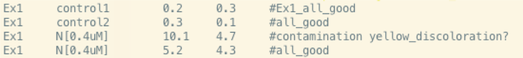

We have a file with

- 4 rows
- 5 columns
- The columns have information for one 1_Inputfiles/Experiment with control and nitrogen measurements (two things were measured)

In this tutorial we learn how to:

- Subset dataframes by columns
- Subset dataframes based on patterns
- Merge dataframes
- etc.

**General info on this tutorial**

- grey box. : The code that we want to execute
- red box. : Urgent comments ;-)
- Code : In some cases the code might be hidden and you only see a little box at the right hand side. Hidden codes means that from the previous sessions you should have enough knowledge to do this step or it is is a test of your skills. If you run into issues you can open the code and check how to run your command by clicking on the `Code` button to reveal the code
- hyperlink : If the text is highlighted like this during a text section, then you can click on it and a hyperlink gives you more info (either the publication or an online tutorial)
- **Exercise:** : This will appear if you should have the required background to finish all the steps yourself. If you run into trouble, you can find the answers if you click the Code butto, which will reveal the answer.
- Sometimes we also just ask questions for you to think about the output of certain programs. The text is then hidden and you have to hover over the “spoiler” to see the answer to the question

# Basic introduction

An essential awk command looks like follows:

**awk ‘instructions’ files**

The Input is read a line at a time. The instructions are enclosed by single quotes to protect them from the shell, since curly brackets or dollars signs are otherwise not interpreted correctly.

Same as with sed, we can issue multiple commands by using a semicolon.

**awk pattern { action }**

- pattern = when the action is performed
- action = what we wanto do

In case we want to run an awk script with more complex commands, we run:

**awk -f script file**

# Subsetting dataframes

1. To test things you can use some files generated for this purpose in the 1_Inputfoles folder.
2. By default the examples below will print to the screen. In case you want to save into a new file you can do parse the output into a new file with a >. Example: **awk command 1_Inputfiles/Experiment1.txt > File_new.txt**
3. The file **1_Inputfiles/Experiment*.txt **contains five columns: The 1_Inputfiles/ExperimentID, conditions, two measurments and a column with some comments. The file** 1_Inputfiles/list** contains a list of addresses, which uses the comma as a separator.
4. If you want to follow this tutorial do the following steps
- Make a new folder inside the workshop directory, name it `Awk_tutorial`
- Go inside that folder
- Copy the folder with the test data from `/export/lv3/scratch/workshop_2021/Sxx_Practice/Awk/1_Inputfiles/`
- familirize yourself with the content of the indiv. files

```bash
#make folder
mkdir Awk_tutorial

#go inside that new folder
cd Awk_tutorial

#get the test data
cp -r /export/lv3/scratch/workshop_2021/Sxx_Practice/Awk/1_Inputfiles/ .

#check files
head 1_Inputfiles/list
head 1_Inputfiles/Experiment1.txt
head 1_Inputfiles/Metadata
head 1_Inputfiles/nameState
```

## Print a column of interest

First, lets learn how we print certain columns, we are interested in.

General info:

- **FS** = input field separator
- **OFS** = Output field separator
- **$0** prints everything
- A **BEGIN** rule is executed once only, before the first input record is read

We can print the entire input line with `$0` or specific input fields (or columns) with `$1` and `$2` and so on.

**Important:**

```bash
#just print column 1
awk '{print $1}' 1_Inputfiles/list
```

**Exercise**: Print the 3rd input field.

```bash
#just print column 1
awk '{print $3}' 1_Inputfiles/list
```

We can also print lines that have specific pattern.

```bash
#just print addresses from MA
awk '$3~ /MA/' 1_Inputfiles/list
```

**Exercise**: Extract the data for Amy

```bash
#qst1
awk '/Amy/' 1_Inputfiles/list
```

In the above example, we specify a pattern but no procedure. When doing this the default action is to print each line that matches the pattern.

We can not only specifiy the pattern but also exactly say what fields we want to print.

```bash
#just print addresses from MA and just print the names
awk '/MA/ {print $1}' 1_Inputfiles/list
```

We can also specify the separator for the different fields using the `-F` option. For example, we can use the comma in our list.

```bash
#just print addresses from MA and just print the names
awk -F, '/MA/ {print $1}' 1_Inputfiles/list
```

If we use this command not only the first but the full name is printed.

**Exercise**: Extract in what street Amy lives

```bash
#just print column 1
awk -F, '/Amy/{print $2}' 1_Inputfiles/list
```

If we want to specify in what colum to look for the data, we do it like this.

```bash
#just print names from MA
awk -F, '$3 ~ /MA/ {print $1}' 1_Inputfiles/list
```

This is esp. useful if MA might also occur in unrelated columns.

If we want to search for two patterns:

```bash
#just print names from MA and PA
awk -F, '$3 ~ /MA|PA/ {print $1}' 1_Inputfiles/list
```

We can also print all names but exclude people from Ma and PA

```bash
#just print names from MA and PA
awk -F, '!/MA|PA/ {print $1,$3}' 1_Inputfiles/list

awk -F, '$3 !~ /MA|PA/ {print $1,$3}' 1_Inputfiles/list
```

## Splitting data by categories

Now imagine we want a separate table with the names of people for each different state, with awk that is relatively easy to do

```bash
#just print names from MA and PA
awk -F, '{print > $3}'  1_Inputfiles/list2

#use ll to see what happened
ls -l

#check the content of a file
head VA
```

To make this a bit nicer, we even can add an extension to the new files that are generaetd

```bash
#just print names from MA and PA
awk -F, '{print > $3".txt"}'  1_Inputfiles/list2

#use ll to see what happened
ls -l

#check the content of a file
head VA.txt
```

We can also just print certain data, i.e. just the names

```bash
#just print names from MA and PA
awk -F, '{print $1 > $3".txt"}'  1_Inputfiles/list2

#use ll to see what happened
ls -l

#check the content of a file
head VA.txt
```

## Combining several actions

We can combine multiple actions by using the semicolon (same as in sed)

```bash
#just print addresses from MA and just print the names
awk -F, '{print $1; print $2; print $3}' 1_Inputfiles/list
```

Options used:

- `-F`: we define the input field delimiter and say to only see the comma as a delimiter not the space

## Print several columns

We can also print any other combination as shown below. Try this by yourself and see what is happening.

```bash
#print column 3 and 4
awk -F, '{print $1, $3}' 1_Inputfiles/list

#print column 3 and 4 and separate them with a minus symbol
awk -F, '{print $1"-"$3}' 1_Inputfiles/list

#print column 3 and 4 and tab separate them
awk -F, '{print $1 "\t" $3}' 1_Inputfiles/list
awk -F, -v OFS="\t" '{print $1, $3}' 1_Inputfiles/list
```

Notice:

- The `"\t"` represents an escaped character and represents a `tab`

Options used:

- `-v OFS="\t"`: we define the output field delimiter as a tab

**Exercise**: Extract in what street and state Amy lives. Separate the columns by a `!`

```bash
#just print column 1
awk -F',' '/Amy/{print $2"!"$3}' 1_Inputfiles/list
```

## Print everything

We can also print everything using `$0`.

```bash
awk '{print $0, $1}' 1_Inputfiles/list
```

Another way to do this is:

```bash
awk '1' 1_Inputfiles/list
```

The above awk command has only the pattern or condition part, no action part. The ‘1’ in the pattern indicates “true” which means true for every line. As said above, no action part denotes just to print which is the default when no action statement is given, and hence the entire file contents get printed.

## Print a column of interest and define the column separators

Now, lets work with a file that uses a tab to separate columns, as this is the type of file we more commonly work with, the file in `1_Inputfiles/Experiment1.txt`

**Something to keep in mind about the default awk behaviour:**

By default awk uses BOTH tabs and spaces as separated, which sometimes can create issues.

Besides using -F and -v OFS to control that behaviour you might also see some different ways that basically do the same thing:

```bash
#Print column 1 and specify that the input separator (-F) is a tab
awk 'BEGIN{FS="\t"}{print $1}' 1_Inputfiles/Experiment1.txt

#Print column 1 and 2 and specify that the input separator (-F) is a tab and the output separator is a comma
awk 'BEGIN{FS="\t";OFS=","}{print $1,$2}' 1_Inputfiles/Experiment1.txt

#print column 1 and then all the columns
awk 'BEGIN{FS=OFS="\t"} {print $1,$0}'  1_Inputfiles/Experiment1.txt
```

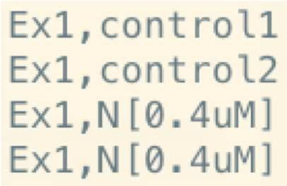

*For the rest of the tutorial we set the OFS and FS as tab as a default.

## Add a column

We can use this if we want to add some extra information into our tables. Later we can also do this a bit more sophisticated using **if/else** statements

```bash
#add a new column in the beginning
awk 'BEGIN{FS=OFS="\t"}{print "redo",$0}' 1_Inputfiles/Experiment1.txt
```

If we run this, we see that we have a new first column followed by the original dataframe.

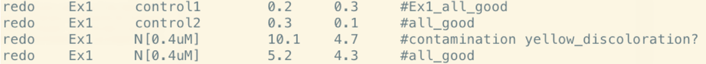

We can exactly control where we add new information. For example, with the code below, we add the extra column between the 2nd and 3rd column of the original dataframe.

```bash
#add a new column as new third column
awk 'BEGIN{FS=OFS="\t"}{print $1,$2,"redo",$3,$4,$5}' 1_Inputfiles/Experiment1.txt
```

**Exercixe**:

Imagine we want to add a column with the T of the experiment. Add a new column at the end with 36C

```bash
#add a new column as new third column
awk 'BEGIN{FS=OFS="\t"}{print $0,"36C"}' 1_Inputfiles/Experiment1.txt
```

## Change the content of an existing column

Let’s say, we do not like to use the word Experiment in our table, but rather would say Repetition. We can change the content of the first column like this:

```bash
#change the content in column 1 to**repetition**
awk 'BEGIN{FS=OFS="\t"}{$1="Repetition1"} {print $0 }' 1_Inputfiles/Experiment1.txt
```

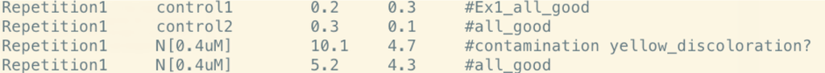

**Exercise**

After plotting the data, we realized that the measurements that we initially labelled as control and N[0.4Um]. We realized we did a mistake and did not change the N levels. Rename everything in column 2 to control.

```bash
#qst1
awk 'BEGIN{FS=OFS="\t"}{$2="control"} {print $0 }' 1_Inputfiles/Experiment1.txt
```

## Split a column

We can also split columns. For example, the Ex1 in the first column, maybe we would want to split before and after the x and print the results into new columns. This is a random example, but when dealing with proteins, you often have something like GenomeName-ProteinID and for some operations we might want to have that information in different columns/

Some new syntax for AWK:

- **split()** = the function ‘split’ divides a string into pieces
- **$1** = The column we want to split
- **“x”** = The pattern we want to use for splitting
- **a** = We name the ARRAY we generate ‘a’. An ARRAY is similar to a variable you just can store more information in the array we store the different pieces that were split
- **a[1]** = retrieve the first part of the split array =E
- **a[2]** = retrieve the second part of the split array =1

Here, we see the output and what our arrays are:

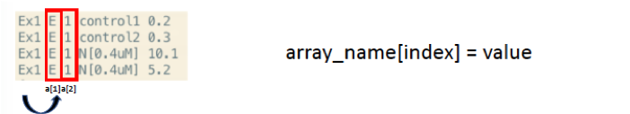

```bash
#split using  **x** in the 1st column and print the two arrays generated in that step
awk 'BEGIN{FS=OFS="\t"}{split($1,a,"x")} {print $1,a[1],a[2],$2,$3}' 1_Inputfiles/Experiment1.txt
```

The output of this line of code should look like this:

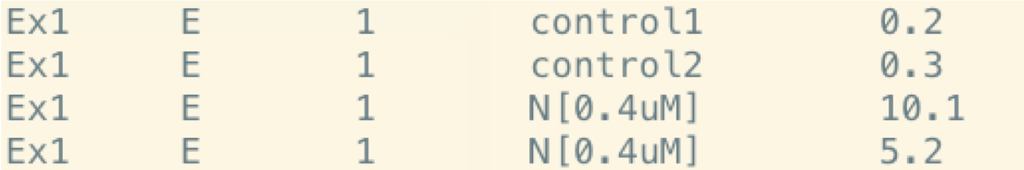

**Exercise**

- In column 5, split after the ’_’. Print the first two columns and the first and second part of the array

```bash
#qst1
awk 'BEGIN{FS=OFS="\t"}{split($5,a,"_")} {print $1,$2,a[1],a[2]}' 1_Inputfiles/Experiment1.txt
```

## Dealing with more than one column

In this example we work with the split function we used above but the syntax stays the same for other commands.

The curly brackets allow us to separate two different commands (version 1). We can also do this by using a semicolon (version 2).

```bash
#version 1
awk -F'\t' -v OFS='\t'  '{split($3,a,".")} {split($4,b,".")} {print $1,$2,a[1],b[1]}' 1_Inputfiles/Experiment1.txt

#version 2
awk -F'\t' -v OFS='\t'  '{split($3,a,"."); split($4,b,"."); print $1,$2,a[1],b[1]}' 1_Inputfiles/Experiment1.txt
```

## Use search and replace

We can search for patterns and if a pattern is found we can replace it with something else. For example, we can search for **Ex** and replace it with **Experiment**

We can also use wildcards here. The default behaviour of wildcards is explained in more detail in the [Unix tutorial](https://github.com/ndombrowski/Unix_tutorial).

```bash
#default
awk -F'\t' -v OFS='\t'  '{gsub(/Ex/,"Experiment")}{print $0}' 1_Inputfiles/Experiment1.txt

#use gsub together with wildcards
#Here, we replace control1 + control2 with blank
awk -F'\t' -v OFS='\t'  '{gsub(/control[12]/,"blank")}{print $0}' 1_Inputfiles/Experiment1.txt
```

The second example looks like this:

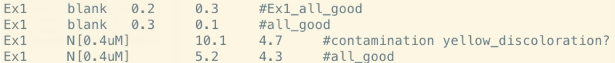

We can see that since we use the wildcard ([12]) both control1 and control2 are replaced with blank.

**Exercise**

- replace the `N[0.4uM]` with `nitrogen`. Do not forget that brackets mean something else for awk and we need to tell it to use the brackets literally. If you do not know how to do this, check the general Unix tutorial
- replace the Ex1 with repetition and the control[12] with blank

```bash
#question1
awk -F'\t' -v OFS='\t'  '{gsub(/N\[0.4uM\]/,"nitrogen")}{print $0}' 1_Inputfiles/Experiment1.txt

#question2
awk -F'\t' -v OFS='\t'  '{gsub(/Ex1/,"Experiment"); gsub(/control[12]/,"blank")}{print $0}' 1_Inputfiles/Experiment1.txt
```

## Only print rows that have a pattern of interest

We can also only print rows that we find relevant. I.e. we might only want to print the columns with our control measurements. Or we might want to only print the information from specific treatments, 1_Inputfiles/Metadata for certain organisms, etc…

New syntax that we use here:

-**?** = Searches for any Number/Letter (exactly one) - **==** = is a logical operator/Boolean expression. This one means find a pattern that is **equal** to the pattern we gave - **!=** = means unequal to - **~** = means find a pattern that is the same AND allow for wildcards - `||` or operator

```bash
#only print rows with control treatments (search across all columns)
awk -F'\t' -v OFS='\t'  '/control?/''{print $0}' 1_Inputfiles/Experiment1.txt

#only print rows if we find the term control2 in column2
awk -F'\t' -v OFS='\t'  '$2=="control2"''{print $0}' 1_Inputfiles/Experiment1.txt

#only print rows wit the control in column2 (AND use wildcards)
awk -F'\t' -v OFS='\t'  '$2~"control?"''{print $0}' 1_Inputfiles/Experiment1.txt

#print everything EXCEPT control2
awk -F'\t' -v OFS='\t'  '$2!="control2"' 1_Inputfiles/Experiment1.txt

#we can search for several patterns arcoss different columns like this
awk -F'\t' -v OFS='\t' '$2 =="N" || $3>6''{print $0}' 1_Inputfiles/Experiment1.txt
```

**Exercise**

- Find the rows in which the experiment was ok and where we did not have issues with contamination (the extra info is stored in column 5)

```bash
awk -F'\t' -v OFS='\t' '$5=="#all_good"''{print $0}' 1_Inputfiles/Experiment1.txt
#or
awk -F'\t' -v OFS='\t' '$5~"good"''{print $0}' 1_Inputfiles/Experiment1.txt
```

## Only print data if a condition is met

Here: Only print rows if the second column has the pattern **N**

```bash
#search pattern across the whole file
awk -F'\t' -v OFS='\t'  '/N/ {print $0}' 1_Inputfiles/Experiment1.txt

#search pattern in specific column
awk -F'\t' -v OFS='\t'  '$2 ~ "N" { print $0 }' 1_Inputfiles/Experiment1.txt
```

## Subset dataframes by using cutoffs and using relational operators

### Relational operators

```bash
awk 'BEGIN {a = 10; b = 10; if (a == b) print "a==b"}'

awk 'BEGIN {a = 10; b = 20; if (a != b) print "a = "a,"b = "b,"therefore", "a!=b"}'

awk 'BEGIN {a = 10; b = 20; if (a <= b) print "a<=b"}'

awk 'BEGIN {a = 10; b = 10; if (a < b) print "a==b"; else print "false"}'
```

We might also want to subset data by numeric values. I.e. we only might want to retain columns were values are larger than 10, or larger than a certain e-value, etc..

This can be very helpful when subsetting blast tables

We can combine two statements using **||** , which means OR Alternatively, we can use **&&** , which means AND

```bash
#only print rows if the third column has values larger than 5
awk -F'\t' -v OFS='\t'  '$3>5' 1_Inputfiles/Experiment1.txt

#if the value in the third column is equal to 5.2 do NOT print
awk -F'\t' -v OFS='\t'  '$3!=5.2' 1_Inputfiles/Experiment1.txt

#if the third column is larger than 5 OR the fourth column is greater than 0.2 then print
awk -F'\t' -v OFS='\t'  '($3>5)||($4>0.2)' 1_Inputfiles/Experiment1.txt

#only print if the values in the third column are equal to or greater than 5
awk -F'\t' -v OFS='\t' '$3>=5.2' 1_Inputfiles/Experiment1.txt

#only print if the third column is equal/larger than 5.2 AND the fourth column is larger than 4.5
awk -F'\t' -v OFS='\t' '($3>=5.2)&&($4>4.5)' 1_Inputfiles/Experiment1.txt
```

**Exercise**

- search for data, where we measured the N treatments and where the value in the third column is greater than 10

```bash
awk -F'\t' -v OFS='\t' '($2~"N")&&($3>10)''{print $0}' 1_Inputfiles/Experiment1.txt
```

## Subsetting data and storing the results into different tables

Remember when we split our list into separate files depending on what states people lived in? We can also do this with number and store numbers smaller than one in a new file.

```bash
awk -F'\t' -v OFS='\t' '{if($3<=1)print > "small.txt";else print > "large.txt"}' 1_Inputfiles/Experiment1.txt

#check if that worked
head small.txt
```

Using a so-called `if-else statement` we say: If it is lesser or equal to 1, the record goes to “smallL.txt”, else to “large.txt”.

## Changing specific cells

This specific command can be quite useful when we for example want to change headers.

Here, we learn several new statements that can be used in AWK:

```bash
#change a the pattern in the 2nd column to **P** if we are in the 3rd ROW
awk 'BEGIN{FS="\t"; OFS="\t"}{if(NR==3) $2="P"} {print $0 }' 1_Inputfiles/Experiment1.txt
```

**Exercise**

We made an error in our comment section (column 5). Instead of `#all_good` for our second measurements, we wanted to write `#stunted_growth`. Correct this error

```bash
#change a the pattern in the 2nd column to **P** if we are in the 3rd ROW
awk 'BEGIN{FS="\t"; OFS="\t"}{if(NR==2) $5="#stunted_growth"} {print $0 }' 1_Inputfiles/Experiment1.txt
```

## AWK and variables

awk provides a “-v” option to pass arguments. Using this, we can pass the shell variable to it

```bash
#define variable
x=3

#add 3 to our third column
awk -v val=$x '{print $0"-->"$3+val}' 1_Inputfiles/Experiment1.txt
```

# Math with awk

### use Arithmetic operators

```bash
awk 'BEGIN {a = 50; b = 20; print "(a + b) = ", (a + b)}'

awk 'BEGIN {a = 50; b = 20; print "(a - b) = ", (a - b)}'

awk 'BEGIN {a = 50; b = 20; print "(a * b) = ", (a * b)}'

awk 'BEGIN {a = 50; b = 20; print "(a / b) = ", (a / b)}'
```

We can also use this on our data tables like this:

```bash
#add the values of the 3rd and 4th column
awk '{print $3+$4}' 1_Inputfiles/Experiment1.txt

#subtract
awk '{print $3-$4}' 1_Inputfiles/Experiment1.txt

#multiply
awk '{print $3*$4}' 1_Inputfiles/Experiment1.txt
```

## Using one variable

Here, we create a variable named **SUM** that stores added values of the 3rd and 4th column. We can use this variable for printing.

```bash
awk '{SUM=$3+$4}{print $1,$2,SUM}' 1_Inputfiles/Experiment1.txt
```

**Exercise**

- Substract column 3 from colum 4 and store the result in a variable with the name ‘diff’. Print the second columnd and diff

```bash
awk '{diff=$4-$3}{print $2,diff}' 1_Inputfiles/Experiment1.txt
```

### Using several variables

Here, we again create the variable **SUM**. Then, we run a second command (using the semicolon) and add a 1 to the values stored in **SUM** and create a new variable named **SUM2**

```bash
awk '{SUM=$3+$4;SUM2=SUM+1}{print $1,$2,SUM,SUM2}' 1_Inputfiles/Experiment1.txt
```

In a more useful way we can use this to create basic functions and for example calculate the average and print it:

```bash
awk '{SUM = $3+$4; avg = SUM/2}{print $1,$2,avg}' 1_Inputfiles/Experiment1.txt
```

### Summarizing data across columns

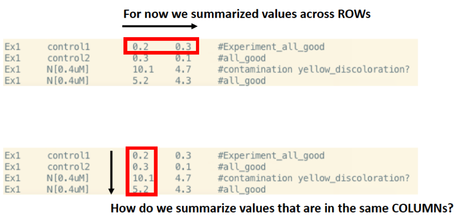

Now, we want to add all the values of the third column together:

- **SUM+** = SUM = the variable we define and ‘+’ = is the summary function
- **2x{}** = 2 action blocks we are executing
- **END** = Execute the 1st action block until the end of the file is reached = marks the end of action block 1

```bash
#using the variable SUM
awk '{SUM+=$3}END{print SUM}' 1_Inputfiles/Experiment1.txt

#using the variable new_name
awk '{New_name+=$3}END{print New_name}' 1_Inputfiles/Experiment1.txt

#add sum text to the results
awk '{SUM+=$3}END{print "The result is",SUM}' 1_Inputfiles/Experiment1.txt

#also here we can combine two actions into one command, i.e. summarize the 3rd and 4th column
awk '{SUM_Col3+=$3;SUMCol4+=$4}END{print SUM_Col3,SUMCol4}' 1_Inputfiles/Experiment1.txt
```

If we do not use **END** this gets messed up, so be careful. Basically without this variable, we consecutively add values within the column and print the individual values. You can check this unwanted behaviour with the code below.

```bash
#not using END
awk '{New_name+=$3}{print New_name}' 1_Inputfiles/Experiment1.txt
```

### Summarizing across columns by using categories

In this example, we want to only summarize the values across our three categories: control1, control2 and N

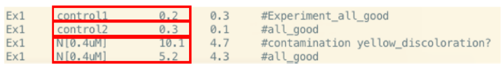

New elements to keep in mind:

- **{SUM[$2]+=$3}** = Sum column3 based on the categories in column2. SUM is stored in an array, where we have 3 indices (i) for control1, control2 and N[0.4uM]
- **for(i in SUM)** = a for loop that loops through our array loop through every of the 3 indices we stored
- **print i** = print each index stored in SUM
- **print SUM[i]** = print each calculated sum stored in the array

```bash
#using the default categories
awk '{SUM[$2]+=$3}END{for(i in SUM) print i,SUM[i]}' 1_Inputfiles/Experiment1.txt

#combining control1 and control2 into one categorie (we use pipes again, Notice we can use pipes to combine different progamms)
sed 's/control[12]/control/g' 1_Inputfiles/Experiment1.txt | awk '{SUM[$2]+=$4}END{for(i in SUM)print i,SUM[i]}'
```

### Using the build in variables

#### The NF command

The NF command is used to keep a count of the fields within the current input record.

```bash
awk '{print  $0"-->"NF;}' 1_Inputfiles/Experiment1.txt
```

**Question**

Why does the 3 row have 6 fields?

Remember that awk usually sees both space and tab as field separator. So without specifying the tab as unique separator, `#contamination yellow_discoloration?` is seen as two separate fields.

#### The NR command

NR gives you the total number of records being processed or line number.

```bash
awk '{print $0"-->"NR;}' 1_Inputfiles/Experiment1.txt
```

#### The Filename command

While this is not math this is incredibly useful if you have thousands of files that you want to merge (as long as you can distinguish them by the file name). For example, if we have the 100 different files with measurements from different 1_Inputfiles/Experiments, we can combine them into one document as long as they have the same layout in terms of nr. of columns and a useful header

```bash
awk '{print FILENAME,$0}' 1_Inputfiles/Experiment1.txt
```

With our example we would get something like this:

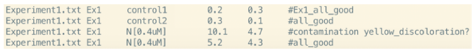

Since, the **.txt** is not pretty we can also remove it by using gsub and a pipe. Pipes are explained in the general notebook but basically allow to combine two commands into one.

```bash
awk '{print FILENAME,$0}' 1_Inputfiles/Experiment1.txt | awk '{gsub(/.txt/,"")}{print $0}'
```

#### The FNR command

When awk reads from the multiple input file, awk NR variable will give the total number of records relative to all the input file. Awk FNR will give you number of records for each input file.

```bash
awk '{print FILENAME, FNR;}' 1_Inputfiles/Experiment1.txt 1_Inputfiles/Metadata
```

### Dealing with headers

Sometimes dealing with headers can be a challenging since they are an extra column we might want to exclude if we for example want to summarize data. Now that we now about special variables, we can deal with this, for example in the `Experiment2.txt` file that comes with a header

```bash
#check how the file looks like
head 1_Inputfiles/Experiment2.txt

#remove the header
awk 'NR!=1{print $0}' 1_Inputfiles/Experiment2.txt
```

**Exercise**

- For Experiment2.txt calculate the sum of the third plus the fourth column. Do this with and without removing the header

```bash
awk 'NR!=1{SUM=$3+$4}{print $1,$2,SUM}' 1_Inputfiles/Experiment2.txt

awk '{SUM=$3+$4}{print $1,$2,SUM}' 1_Inputfiles/Experiment2.txt
```

### use Increment and decrement operators

```bash
awk 'BEGIN {a = 10; b = ++a; print b}'

awk 'BEGIN {a = 10; b = ++a; printf "a = %d, b = %d\n", a, b}'

awk 'BEGIN {a = 10; b = --a; printf "a = %d, b = %d\n", a, b}'

awk 'BEGIN {a = 10; b = a--; printf "a = %d, b = %d\n", a, b}'
```

We could for example tell awk to count the number of lines in which a specified pattern is matched and then output that ‘count’. For example, lets count how often we did control measurements?

```bash
awk '/control/{++cnt} END {print "Count = ", cnt}'  1_Inputfiles/Experiment1.txt
```

**Exercise**

- Count how often the experiment was good
- Count how many control measurements and how many nitrogen measurements we have. Do not forget about your semicolons.

```bash
#qst1
awk '/good/{++cnt} END {print "Count = ", cnt}'  1_Inputfiles/Experiment1.txt

#qst2
awk '/control/{++cnt_c};/N/{++cnt_n} END {print "Count control = ", cnt_c, "Count nitrogen = ", cnt_n}'  1_Inputfiles/Experiment1.txt
```

# Merging tables

Inside the file *1_Inputfiles/Metadata* we have some additional information on how we did our different 1_Inputfiles/Experiments. I.e. the date, temperature and how long they were run. With awk we can add this info into our 1_Inputfiles/Experiment1.txt table.

New things to learn:

- **FNR** = record number (typically the line number per file)
- **NR** = total record number across files
- **==** = comparison operator that means equal to
- **a[$1]** = We use the 1st Column of 1_Inputfiles/Metadata as our KEY = do we find the ‘Ex1’ in 1_Inputfiles/Metadata also in 1_Inputfiles/Experiment1.txt?
- **a[$1]=$0** = in 1_Inputfiles/Metadata use first column as key AND store the info from all the columns. If we only would want to have the fourth column we could use **a[$1]=$4**

```bash
awk 'FNR==NR{a[$1]=$0;next}{print $0,a[$1]}' 1_Inputfiles/Metadata 1_Inputfiles/Experiment1.txt
```

If you are interested in how the first command works **FNR==NR** we can break this down to

```bash
awk '{print "NR:", NR " FNR:", FNR}' 1_Inputfiles/Metadata 1_Inputfiles/Experiment1.txt
```

Which will give this:

[figure not shown]

The **next** statement means: the print statement is only executed after we stored the data from 1_Inputfiles/Metadata1 (using FNR==NR). If we do not use next we record 1_Inputfiles/Metadata1 but do not “store” it in the background and print in one go.

Below you can test what happens if we do not use **next**

```bash
#example without using next
awk 'FNR==NR{a[$1]=$0}{print $0,a[$1]}' 1_Inputfiles/Metadata 1_Inputfiles/Experiment1.txt`
```

The KEY **a[$1]** is important as it tells awk were to look for a common pattern that can be used for merging. In this example, both columns have **Ex1** in the first column. If we use the second column, that has no common pattern, nothing would be merged.

# AWK and sed

AWK and sed generally work nicely together and we can combine these two programs for our purposes using the `|` symbol.

As an example, lets assume we already have a sed script ready that replaces the names for the states in `cat 1_Inputfiles/nameState` and we can use this script to pipe it into awk. Before running the command, make sure to have a look at the sed script to understand what is happening.

```bash
#check the sed script
head 1_Inputfiles/nameState
```

We can see that we defined several lines of search and replace patterns. I.e we want sed to

- replace `MA` with `Massachusetts`
- replace `PA` with `Pennsylvania`
- and so on…

So we prepared a file with several search and replace patterns, which we can feed into sed with `-f`

```bash
#clean up the state names
sed -f 1_Inputfiles/nameState 1_Inputfiles/list
```

If we use our pipes we can then use awk to only print the state names

```bash
#print the state names only
sed -f 1_Inputfiles/nameState 1_Inputfiles/list | awk -F, '{print $4}'
```

In this example, awk is processing the output produced by the sed script.

# AWK scripts

Same as for sed, we can write awk scripts if your commands get more complicated.

For example we ant to make a list for each state that lists who lives in that state

For example, we can store a script that we open with `nano byState` and inside the script we store the following lines:

```bash
#! /bin/sh
awk -F, '{print $4 ", " $0}' $* |
sort |
awk -F, '
$1 == LastState{print "\t" $2}
$1 != LastState{LastState = $1
      print $1
      print "\t" $2}
'
```

We execute this script like this:

```bash
sed -f 1_Inputfiles/nameState 1_Inputfiles/list | sh byState
```

To try to dissect things it is always useful to split a script apart, i.e. we can run the first lines like this

```bash
#step1
sed -f 1_Inputfiles/nameState 1_Inputfiles/list | awk -F, '{print $4 ", " $0}'

#step2
sed -f 1_Inputfiles/nameState 1_Inputfiles/list | awk -F, '{print $4 ", " $0}' | sort

#step3
sed -f 1_Inputfiles/nameState 1_Inputfiles/list | awk -F, '{print $4 ", " $0}' | sort | awk -F, '$1 == LastState{print "\t" $2}$1 != LastState{LastState = $1;print $1; print "\t" $2}'
```

We see that the script:

1. Adjust the state name (that is the sed part is doing this)
2. We put the state name into the first column
3. We sort by the different states

In the second part of the command, we do some programming:

1. We look at the first field of each record (the state) and we check if it is the same as in the previous record.
2. If they are not the same, the name of the state is printed followed by the persons name
3. If they are the same then only the persons name is printed